# Data 622 Homework 4

Sung Lee

2022-05-04

[RPubs Link](https://rpubs.com/logicalschema/data622_hw4)

[GitHub Link](https://github.com/logicalschema/spring2022/tree/main/data622/hw4)

# Assignment

You get to decide which dataset you want to work on. THe data set must be different You can work on a problem from your work, or something you are interested in. You may also obtain a dataset from sites such as Kaggle, Data.Gov, Census Bureau, USGS or other open data portal. Select one of the methodologies studied in weeks 1-10, and one methodology from weeks 11-15 to apply in the new dataset selected. To complete this task:. - describe the problem you are trying to solve. - describe your datasets and what you did to prepare the data for analysis. - methodologies you used for analyzing the data - why you did what you did - make your conclusions from your analysis. Please be sure to address the business impact (it could be of any domain) of your solution. Your final presentation could be the traditional R file and essay, or it could be an oral presentation with the execution and explanation of your code, recorded on any platform of your choice (Youtube, Free Cam). If you select the presentation, it should be a 5 to 8 minutes recording.

## Problem

The topic of selecting a middle school was a selfish one for me because my child is set to attend middle school in New York City. NYC’s public school system is difficult to navigate and as a parent I sought to select a middle school with an increased likelihood of students attending a specialized high school. The main problem I wish to solve is to select a middle school for my child to attend with an increased likelihood of students attending a specialized high school.

Every year over 25,000 eighth grade students in New York City’s public school system take the arduous Specialized High School Admissions Test (SHSAT) to gain admittance to eight prestigious specialized high schools: Bronx High School of Science, Brooklyn Latin School, Brooklyn Technical High School, the High School for Mathematics, Science and Engineering at City College of New York, High School of American Studies at Lehman College, Queens High School for the Sciences at York College, Staten Island Technical High School, and Stuyvesant High School. Yet with a population of over 1 million students, the largest system in the United States, is there equity in the system to allow admittance? It is the plan of this research to look at the data for New York City’s school system for the years of 2018 to 2021 with regards to middle schools and the SHSAT. The system is divided into 32 school districts. This study will examine middle school data to see if there is a correlation between the number of offers given for specialized high school based on the SHSAT and an individual school’s academic data, programs, and district assignment. It is the hope of this study to identify trends for improving success for schools and to, if any, to determine ways to improve schools that have few offers.

## Datasets

The following data sets were used for this homework.

- [Map of NYC school Districts](https://data.cityofnewyork.us/Education/School-Districts/r8nu-ymqj)
- [NYC Open Data for Middle School Directories](https://data.cityofnewyork.us/browse?q=Middle%20School%20Directory&sortBy=relevance)
- [NYC Open Data for SHSAT Admission Offiers 2018-2021](https://data.cityofnewyork.us/browse?q=SHSAT&sortBy=relevance)

## Reasoning

Looking at the NYC Open Data, the data for middle schools proved to only be viable for 2018 to 2021. In addition, the data sources would report a range of 0-5 for offers. Hence, if a middle school received 0 offers for students, the row would have a value of “0 to 5”. I decided to list such values as 0 in addition to removing middle schools with “NA” values for student counts: the reason is that in some years the middle school may not have reported the data or did not exist.  
Later in the exploration of models, I found that issues with overdispersion and would need to employ zero-inflation modelling methods.

# Methodology

## Exploratory Data Analysis

For the exploratory data analysis, I decided early to create maps that would help me grapple with the location of middle schools and their SHSAT performance. The following were coded in Python and R using `Plotly` and `Shiny` libraries.

- [SHSAT Plotly App](https://sslee-specializedhs.azurewebsites.net/)
- [SHSAT Shiny App](https://logicalschema.shinyapps.io/NYC_DOE_SHSAT/)

[figure not shown]

***

[figure not shown]

https://sslee-specializedhs.azurewebsites.net/

The following code imports that data sets that were created after cleaning.

```r
# School information: Note: only 2018-2021 are available
school_info <- read_csv('https://raw.githubusercontent.com/logicalschema/spring2022/main/data622/hw4/data/2018-2021_school_information.csv')
# Remove NA values for total_students, course pass rate, elaprof, and mathprof
school_info <- school_info %>% drop_na(totalstudents)
school_info <- school_info %>% drop_na(coursepassrate)
school_info <- school_info %>% drop_na(elaprof)
school_info <- school_info %>% drop_na(mathprof)

# Convert totalstudents to numberical
school_info$totalstudents <- as.numeric(as.character(school_info$totalstudents))
# Potential features
## Dual Program feature: If the school has a dual language program
school_info$dual_program <- ifelse(str_detect(school_info$ellprograms, "Dual") & (is.na(school_info$ellprograms) == FALSE), 1, 0)

## Specialized Test Prep feature: If the school has a specialized high school prep class
school_info$shsat_prep <- ifelse(str_detect(school_info$electiveclasses, "Specialized High School Test") & (is.na(school_info$electiveclasses) == FALSE), 1, 0)

# School offers have the offers for middle schools: Note 2016-2021 are available but for the previous data set only 2018-2021 are available
# Remove rows with NA values
school_offers <- read_csv('https://raw.githubusercontent.com/logicalschema/spring2022/main/data622/hw4/data/school_offers.csv')
school_offers$Postcode <- as.character(school_offers$Postcode)
school_offers <- subset(school_offers, select = -c(`name`, `telephone`, `address`, `2016_student_count`,                                  `2016_testers_count`,`2016_offers_count`,`2017_student_count`,`2017_testers_count`,`2017_offers_count`))
school_offers <- na.omit(school_offers)

temp1 <- subset(school_info, select = c(`district`, `schooldbn`, `name`, `year`, `coursepassrate`, `accessibility`, `elaprof`, `mathprof`, `totalstudents`, `surveysafety`,`dual_program`, `shsat_prep`))


temp2018 <- merge(temp1[temp1$year == 2018, ], subset(school_offers, select = c(`dbn`, `2018_student_count`, `2018_testers_count`, `2018_offers_count`)), by.x = 'schooldbn', by.y='dbn')

names(temp2018)[names(temp2018) == '2018_student_count'] <- 'student_count'
names(temp2018)[names(temp2018) == '2018_testers_count'] <- 'testers_count'
names(temp2018)[names(temp2018) == '2018_offers_count'] <- 'offers_count'


temp2019 <- merge(temp1[temp1$year == 2019, ], subset(school_offers, select = c(`dbn`, `2019_student_count`, `2019_testers_count`, `2019_offers_count`)), by.x = 'schooldbn', by.y='dbn')

names(temp2019)[names(temp2019) == '2019_student_count'] <- 'student_count'
names(temp2019)[names(temp2019) == '2019_testers_count'] <- 'testers_count'
names(temp2019)[names(temp2019) == '2019_offers_count'] <- 'offers_count'

temp2020 <- merge(temp1[temp1$year == 2020, ], subset(school_offers, select = c(`dbn`, `2020_student_count`, `2020_testers_count`, `2020_offers_count`)), by.x = 'schooldbn', by.y='dbn')

names(temp2020)[names(temp2020) == '2020_student_count'] <- 'student_count'
names(temp2020)[names(temp2020) == '2020_testers_count'] <- 'testers_count'
names(temp2020)[names(temp2020) == '2020_offers_count'] <- 'offers_count'

temp2021 <- merge(temp1[temp1$year == 2021, ], subset(school_offers, select = c(`dbn`, `2021_student_count`, `2021_testers_count`, `2021_offers_count`)), by.x = 'schooldbn', by.y='dbn')

names(temp2021)[names(temp2021) == '2021_student_count'] <- 'student_count'
names(temp2021)[names(temp2021) == '2021_testers_count'] <- 'testers_count'
names(temp2021)[names(temp2021) == '2021_offers_count'] <- 'offers_count'


# Create model data and concatenate the temp data frames
model_data <- rbind(temp2018, temp2019)
model_data <- rbind(model_data, temp2020)
model_data <- rbind(model_data, temp2021)


# Create rate_offers: number of offers / number of testers
model_data$rate_offers <- model_data$offers_count / model_data$testers_count
model_data$rate_offers[is.na(model_data$rate_offers)] <- 0

# Temp variables for schools
schools2018 <- model_data[model_data$year == 2018, ]
schools2019 <- model_data[model_data$year == 2019, ]
schools2020 <- model_data[model_data$year == 2020, ]
schools2021 <- model_data[model_data$year == 2021, ]
```

## Years 2018 to 2021

The following tabs represent a visual analysis of the data for the years 2018 to 2021. The top 25 middle schools with the highest rate of offers to specialized high schools for each year is also listed. Notable schools such as the Christa McAuliffe School would consistently be at the top for high performing middle schools.

### 2018

```r
print(dfSummary(schools2018, graph.magnif=0.75), method="render")
```

Data Frame Summary

schools2018

**Dimensions**: 207 x 16  
**Duplicates**: 0

| **No** | **Variable** | **Stats / Values** | **Freqs (% of Valid)** | **Graph** | **Valid** | **Missing** |
| --- | --- | --- | --- | --- | --- | --- |
| 1 | schooldbn [character] | 1. 01M034 2. 01M140 3. 01M184 4. 01M188 5. 01M332 6. 01M378 7. 01M450 8. 01M539 9. 01M839 10. 05M123 [ 197 others ] | 1 ( 0.5% ) 1 ( 0.5% ) 1 ( 0.5% ) 1 ( 0.5% ) 1 ( 0.5% ) 1 ( 0.5% ) 1 ( 0.5% ) 1 ( 0.5% ) 1 ( 0.5% ) 1 ( 0.5% ) 197 ( 95.2% ) |  | 207 (100.0%) | 0 (0.0%) |
| 2 | district [numeric] | Mean (sd) : 17.5 (8.6) min ≤ med ≤ max: 1 ≤ 20 ≤ 31 IQR (CV) : 13 (0.5) | 16 distinct values |  | 207 (100.0%) | 0 (0.0%) |
| 3 | name [character] | 1. Academy for College Prepa 2. Academy of Applied Mathem 3. Academy of Arts and Lette 4. Academy of Medical Techno 5. ACCION Academy 6. Adrien Block (I.S. 25) 7. Alfred De B. Mason (P.S./ 8. America'… | 1 ( 0.5% ) 1 ( 0.5% ) 1 ( 0.5% ) 1 ( 0.5% ) 1 ( 0.5% ) 1 ( 0.5% ) 1 ( 0.5% ) 1 ( 0.5% ) 1 ( 0.5% ) 1 ( 0.5% ) 197 ( 95.2% ) |  | 207 (100.0%) | 0 (0.0%) |
| 4 | year [numeric] | 1 distinct value | 2018 : 207 ( 100.0% ) |  | 207 (100.0%) | 0 (0.0%) |
| 5 | coursepassrate [numeric] | Mean (sd) : 91.3 (10.6) min ≤ med ≤ max: 28 ≤ 95 ≤ 100 IQR (CV) : 9 (0.1) | 33 distinct values |  | 207 (100.0%) | 0 (0.0%) |
| 6 | accessibility [character] | 1. Accessible 2. Not Accessible | 120 ( 58.0% ) 87 ( 42.0% ) |  | 207 (100.0%) | 0 (0.0%) |
| 7 | elaprof [numeric] | Mean (sd) : 35.2 (20) min ≤ med ≤ max: 4 ≤ 30 ≤ 95 IQR (CV) : 28.5 (0.6) | 73 distinct values |  | 207 (100.0%) | 0 (0.0%) |
| 8 | mathprof [numeric] | Mean (sd) : 32.3 (23.4) min ≤ med ≤ max: 2 ≤ 26 ≤ 97 IQR (CV) : 36 (0.7) | 79 distinct values |  | 207 (100.0%) | 0 (0.0%) |
| 9 | totalstudents [numeric] | Mean (sd) : 477.7 (451.1) min ≤ med ≤ max: 38 ≤ 278 ≤ 2175 IQR (CV) : 291.5 (0.9) | 172 distinct values |  | 207 (100.0%) | 0 (0.0%) |
| 10 | surveysafety [numeric] | Mean (sd) : 84.1 (8.5) min ≤ med ≤ max: 59 ≤ 85 ≤ 100 IQR (CV) : 10 (0.1) | 40 distinct values |  | 207 (100.0%) | 0 (0.0%) |
| 11 | dual_program [numeric] | Min : 0 Mean : 0.1 Max : 1 | 0 : 186 ( 89.9% ) 1 : 21 ( 10.1% ) |  | 207 (100.0%) | 0 (0.0%) |
| 12 | shsat_prep [numeric] | Min : 0 Mean : 0 Max : 1 | 0 : 204 ( 98.6% ) 1 : 3 ( 1.4% ) |  | 207 (100.0%) | 0 (0.0%) |
| 13 | student_count [numeric] | Mean (sd) : 160.7 (152.9) min ≤ med ≤ max: 15 ≤ 93 ≤ 769 IQR (CV) : 86.5 (1) | 130 distinct values |  | 207 (100.0%) | 0 (0.0%) |
| 14 | testers_count [numeric] | Mean (sd) : 55.6 (77.5) min ≤ med ≤ max: 0 ≤ 22 ≤ 394 IQR (CV) : 59.5 (1.4) | 92 distinct values |  | 207 (100.0%) | 0 (0.0%) |
| 15 | offers_count [numeric] | Mean (sd) : 11.3 (28.5) min ≤ med ≤ max: 0 ≤ 0 ≤ 205 IQR (CV) : 8 (2.5) | 39 distinct values |  | 207 (100.0%) | 0 (0.0%) |
| 16 | rate_offers [numeric] | Mean (sd) : 0.1 (0.1) min ≤ med ≤ max: 0 ≤ 0 ≤ 0.8 IQR (CV) : 0.1 (1.9) | 62 distinct values |  | 207 (100.0%) | 0 (0.0%) |

Generated by summarytools 1.0.0 ([R](https://www.r-project.org/) version 4.1.3)  
2022-05-04

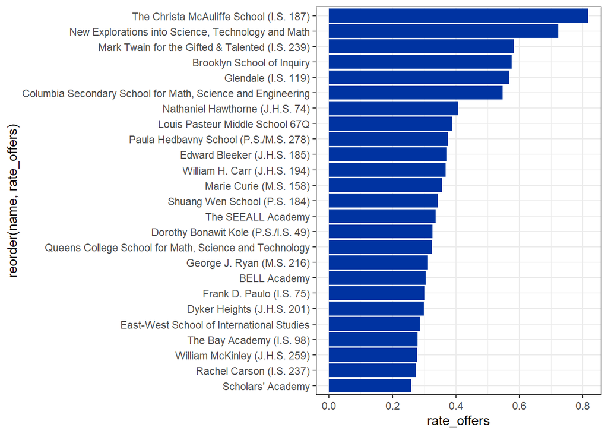

```r
ggplot( head(arrange(schools2018, desc(rate_offers)), n = 25), aes(x= reorder(name, rate_offers), y=rate_offers) ) +
  geom_bar(stat = "identity", fill="#0033a1") +
  coord_flip() +
  theme_bw()
```

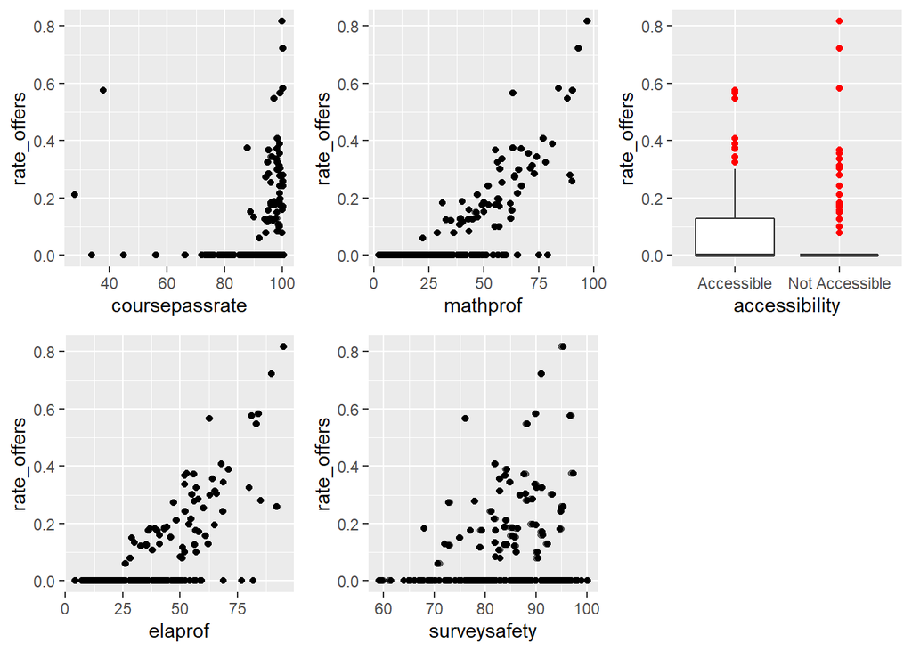

```r
p1 <- ggplot(data=model_data[model_data$year == 2018, ], aes(x=coursepassrate, y=rate_offers)) + geom_point(alpha=0.5) + geom_jitter()
p2 <- ggplot(data=model_data[model_data$year == 2018, ], aes(x=elaprof, y=rate_offers)) + geom_point(alpha=0.5) + geom_jitter()
p3 <- ggplot(data=model_data[model_data$year == 2018, ], aes(x=mathprof, y=rate_offers)) + geom_point(alpha=0.5) + geom_jitter()
p4 <- ggplot(data=model_data[model_data$year == 2018, ], aes(x=surveysafety, y=rate_offers)) + geom_point(alpha=0.5) + geom_jitter()
p5 <- ggplot(data=model_data[model_data$year == 2018, ], aes(x=accessibility, y=rate_offers)) + geom_boxplot() + geom_boxplot(outlier.colour = "red")

multiplot(p1, p2, p3, p4, p5, cols=3)
```

```r
# Cor plots
ggcorr(schools2021[, c(5,7,8,9,10,11,12,13,14,15,16)], label = T, hjust= 0.9)
```

[output not shown]

### 2019

```r
print(dfSummary(schools2019, graph.magnif=0.75), method="render")
```

Data Frame Summary

schools2019

**Dimensions**: 455 x 16  
**Duplicates**: 0

| **No** | **Variable** | **Stats / Values** | **Freqs (% of Valid)** | **Graph** | **Valid** | **Missing** |
| --- | --- | --- | --- | --- | --- | --- |
| 1 | schooldbn [character] | 1. 01M034 2. 01M140 3. 01M184 4. 01M188 5. 01M332 6. 01M378 7. 01M450 8. 01M539 9. 01M839 10. 02M104 [ 445 others ] | 1 ( 0.2% ) 1 ( 0.2% ) 1 ( 0.2% ) 1 ( 0.2% ) 1 ( 0.2% ) 1 ( 0.2% ) 1 ( 0.2% ) 1 ( 0.2% ) 1 ( 0.2% ) 1 ( 0.2% ) 445 ( 97.8% ) |  | 455 (100.0%) | 0 (0.0%) |
| 2 | district [numeric] | Mean (sd) : 16 (9.4) min ≤ med ≤ max: 1 ≤ 15 ≤ 32 IQR (CV) : 16.5 (0.6) | 32 distinct values |  | 455 (100.0%) | 0 (0.0%) |
| 3 | name [character] | 1. Daniel Carter Beard (J.H 2. J.H.S. 74 Nathaniel Hawt 3. 47 - PS 347 The American 4. Academy for College Prepa 5. Academy for New Americans 6. Academy For Personal Lead 7. Academy for Young Writer… | 1 ( 0.2% ) 1 ( 0.2% ) 1 ( 0.2% ) 1 ( 0.2% ) 1 ( 0.2% ) 1 ( 0.2% ) 1 ( 0.2% ) 1 ( 0.2% ) 1 ( 0.2% ) 1 ( 0.2% ) 445 ( 97.8% ) |  | 455 (100.0%) | 0 (0.0%) |
| 4 | year [numeric] | 1 distinct value | 2019 : 455 ( 100.0% ) |  | 455 (100.0%) | 0 (0.0%) |
| 5 | coursepassrate [numeric] | Mean (sd) : 90.7 (9) min ≤ med ≤ max: 40 ≤ 93 ≤ 100 IQR (CV) : 11 (0.1) | 41 distinct values |  | 455 (100.0%) | 0 (0.0%) |
| 6 | accessibility [character] | 1. Accessible 2. Not Accessible 3. Accessible 4. Fully Accessible 5. Not Accessible 6. Partially Accessible | 1 ( 0.2% ) 1 ( 0.2% ) 4 ( 0.9% ) 89 ( 19.6% ) 194 ( 42.7% ) 165 ( 36.3% ) |  | 454 (99.8%) | 1 (0.2%) |
| 7 | elaprof [numeric] | Mean (sd) : 37.7 (20.9) min ≤ med ≤ max: 1 ≤ 32 ≤ 100 IQR (CV) : 28 (0.6) | 88 distinct values |  | 455 (100.0%) | 0 (0.0%) |
| 8 | mathprof [numeric] | Mean (sd) : 31 (23.6) min ≤ med ≤ max: 0 ≤ 24 ≤ 100 IQR (CV) : 33 (0.8) | 96 distinct values |  | 455 (100.0%) | 0 (0.0%) |
| 9 | totalstudents [numeric] | Mean (sd) : 627.7 (397) min ≤ med ≤ max: 70 ≤ 525.5 ≤ 2238 IQR (CV) : 454 (0.6) | 362 distinct values |  | 454 (99.8%) | 1 (0.2%) |
| 10 | surveysafety [numeric] | Mean (sd) : 83.4 (9.2) min ≤ med ≤ max: 19 ≤ 85 ≤ 100 IQR (CV) : 12 (0.1) | 44 distinct values |  | 455 (100.0%) | 0 (0.0%) |
| 11 | dual_program [numeric] | Min : 0 Mean : 0.1 Max : 1 | 0 : 398 ( 87.5% ) 1 : 57 ( 12.5% ) |  | 455 (100.0%) | 0 (0.0%) |
| 12 | shsat_prep [numeric] | Min : 0 Mean : 0 Max : 1 | 0 : 448 ( 98.5% ) 1 : 7 ( 1.5% ) |  | 455 (100.0%) | 0 (0.0%) |
| 13 | student_count [numeric] | Mean (sd) : 148.3 (130.6) min ≤ med ≤ max: 11 ≤ 100 ≤ 773 IQR (CV) : 97.5 (0.9) | 217 distinct values |  | 455 (100.0%) | 0 (0.0%) |
| 14 | testers_count [numeric] | Mean (sd) : 47.8 (64.1) min ≤ med ≤ max: 0 ≤ 25 ≤ 352 IQR (CV) : 41.5 (1.3) | 131 distinct values |  | 455 (100.0%) | 0 (0.0%) |
| 15 | offers_count [numeric] | Mean (sd) : 8.2 (23.3) min ≤ med ≤ max: 0 ≤ 0 ≤ 195 IQR (CV) : 6 (2.8) | 51 distinct values |  | 455 (100.0%) | 0 (0.0%) |
| 16 | rate_offers [numeric] | Mean (sd) : 0.1 (0.1) min ≤ med ≤ max: 0 ≤ 0 ≤ 0.8 IQR (CV) : 0.1 (2.2) | 111 distinct values |  | 455 (100.0%) | 0 (0.0%) |

Generated by summarytools 1.0.0 ([R](https://www.r-project.org/) version 4.1.3)  
2022-05-04

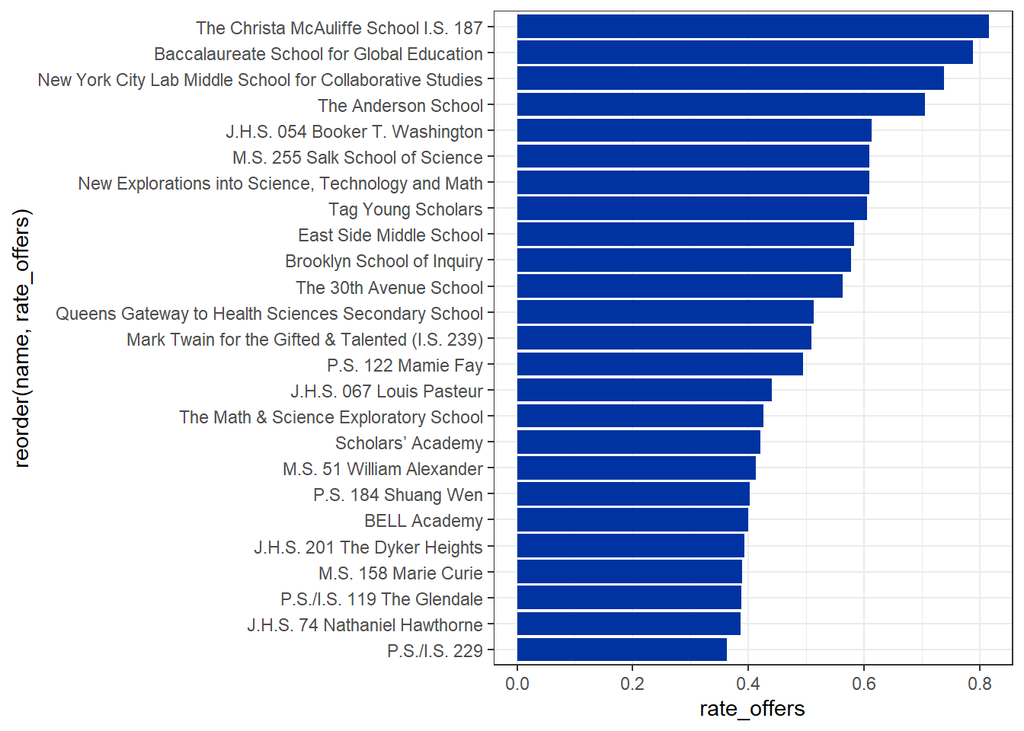

```r
ggplot( head(arrange(schools2019, desc(rate_offers)), n = 25), aes(x= reorder(name, rate_offers), y=rate_offers) ) +
  geom_bar(stat = "identity", fill="#0033a1") +
  coord_flip() +
  theme_bw()
```

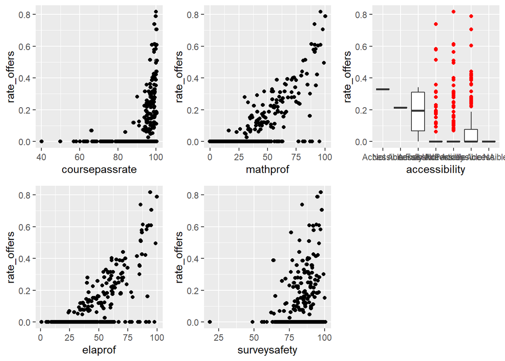

```r
p1 <- ggplot(data=model_data[model_data$year == 2019, ], aes(x=coursepassrate, y=rate_offers)) + geom_point(alpha=0.5) + geom_jitter()
p2 <- ggplot(data=model_data[model_data$year == 2019, ], aes(x=elaprof, y=rate_offers)) + geom_point(alpha=0.5) + geom_jitter()
p3 <- ggplot(data=model_data[model_data$year == 2019, ], aes(x=mathprof, y=rate_offers)) + geom_point(alpha=0.5) + geom_jitter()
p4 <- ggplot(data=model_data[model_data$year == 2019, ], aes(x=surveysafety, y=rate_offers)) + geom_point(alpha=0.5) + geom_jitter()
p5 <- ggplot(data=model_data[model_data$year == 2019, ], aes(x=accessibility, y=rate_offers)) + geom_boxplot() + geom_boxplot(outlier.colour = "red")

multiplot(p1, p2, p3, p4, p5, cols=3)
```

```r
# Cor plots
ggcorr(schools2021[, c(5,7,8,9,10,11,12,13,14,15,16)], label = T, hjust= 0.9)
```

[output not shown]

### 2020

```r
print(dfSummary(schools2020, graph.magnif=0.75), method="render")
```

Data Frame Summary

schools2020

**Dimensions**: 456 x 16  
**Duplicates**: 0

| **No** | **Variable** | **Stats / Values** | **Freqs (% of Valid)** | **Graph** | **Valid** | **Missing** |
| --- | --- | --- | --- | --- | --- | --- |
| 1 | schooldbn [character] | 1. 01M034 2. 01M140 3. 01M184 4. 01M188 5. 01M332 6. 01M378 7. 01M450 8. 01M539 9. 01M839 10. 02M104 [ 446 others ] | 1 ( 0.2% ) 1 ( 0.2% ) 1 ( 0.2% ) 1 ( 0.2% ) 1 ( 0.2% ) 1 ( 0.2% ) 1 ( 0.2% ) 1 ( 0.2% ) 1 ( 0.2% ) 1 ( 0.2% ) 446 ( 97.8% ) |  | 456 (100.0%) | 0 (0.0%) |
| 2 | district [numeric] | Mean (sd) : 15.9 (9.4) min ≤ med ≤ max: 1 ≤ 15 ≤ 32 IQR (CV) : 16 (0.6) | 32 distinct values |  | 456 (100.0%) | 0 (0.0%) |
| 3 | name [character] | 1. Academy for College Prepa 2. Academy For Personal Lead 3. Academy for Young Writers 4. Academy of Applied Mathem 5. Academy of Arts and Lette 6. Academy of Medical Techno 7. Academy of Public Relat… | 1 ( 0.2% ) 1 ( 0.2% ) 1 ( 0.2% ) 1 ( 0.2% ) 1 ( 0.2% ) 1 ( 0.2% ) 1 ( 0.2% ) 1 ( 0.2% ) 1 ( 0.2% ) 1 ( 0.2% ) 446 ( 97.8% ) |  | 456 (100.0%) | 0 (0.0%) |
| 4 | year [numeric] | 1 distinct value | 2020 : 456 ( 100.0% ) |  | 456 (100.0%) | 0 (0.0%) |
| 5 | coursepassrate [numeric] | Mean (sd) : 91.4 (9) min ≤ med ≤ max: 27 ≤ 94 ≤ 100 IQR (CV) : 10 (0.1) | 41 distinct values |  | 456 (100.0%) | 0 (0.0%) |
| 6 | accessibility [character] | 1. Fully Accessible 2. Not Accessible 3. Partially Accessible | 115 ( 25.2% ) 185 ( 40.6% ) 156 ( 34.2% ) |  | 456 (100.0%) | 0 (0.0%) |
| 7 | elaprof [numeric] | Mean (sd) : 43.7 (21.1) min ≤ med ≤ max: 7 ≤ 39 ≤ 100 IQR (CV) : 30 (0.5) | 84 distinct values |  | 456 (100.0%) | 0 (0.0%) |
| 8 | mathprof [numeric] | Mean (sd) : 35.4 (23.7) min ≤ med ≤ max: 2 ≤ 28 ≤ 100 IQR (CV) : 35 (0.7) | 91 distinct values |  | 456 (100.0%) | 0 (0.0%) |
| 9 | totalstudents [numeric] | Mean (sd) : 634.4 (396.9) min ≤ med ≤ max: 94 ≤ 534.5 ≤ 2251 IQR (CV) : 440.2 (0.6) | 366 distinct values |  | 456 (100.0%) | 0 (0.0%) |
| 10 | surveysafety [numeric] | Mean (sd) : 83.2 (8.2) min ≤ med ≤ max: 58 ≤ 84 ≤ 100 IQR (CV) : 10.2 (0.1) | 42 distinct values |  | 456 (100.0%) | 0 (0.0%) |
| 11 | dual_program [numeric] | Min : 0 Mean : 0.1 Max : 1 | 0 : 394 ( 86.4% ) 1 : 62 ( 13.6% ) |  | 456 (100.0%) | 0 (0.0%) |
| 12 | shsat_prep [numeric] | 1 distinct value | 0 : 456 ( 100.0% ) |  | 456 (100.0%) | 0 (0.0%) |
| 13 | student_count [numeric] | Mean (sd) : 145.1 (130.9) min ≤ med ≤ max: 11 ≤ 96 ≤ 772 IQR (CV) : 89.2 (0.9) | 210 distinct values |  | 456 (100.0%) | 0 (0.0%) |
| 14 | testers_count [numeric] | Mean (sd) : 47.4 (65.2) min ≤ med ≤ max: 0 ≤ 23.5 ≤ 369 IQR (CV) : 45 (1.4) | 133 distinct values |  | 456 (100.0%) | 0 (0.0%) |
| 15 | offers_count [numeric] | Mean (sd) : 7.2 (21.2) min ≤ med ≤ max: 0 ≤ 0 ≤ 214 IQR (CV) : 0 (2.9) | 48 distinct values |  | 456 (100.0%) | 0 (0.0%) |
| 16 | rate_offers [numeric] | Mean (sd) : 0.1 (0.1) min ≤ med ≤ max: 0 ≤ 0 ≤ 0.8 IQR (CV) : 0 (2.3) | 104 distinct values |  | 456 (100.0%) | 0 (0.0%) |

Generated by summarytools 1.0.0 ([R](https://www.r-project.org/) version 4.1.3)  
2022-05-04

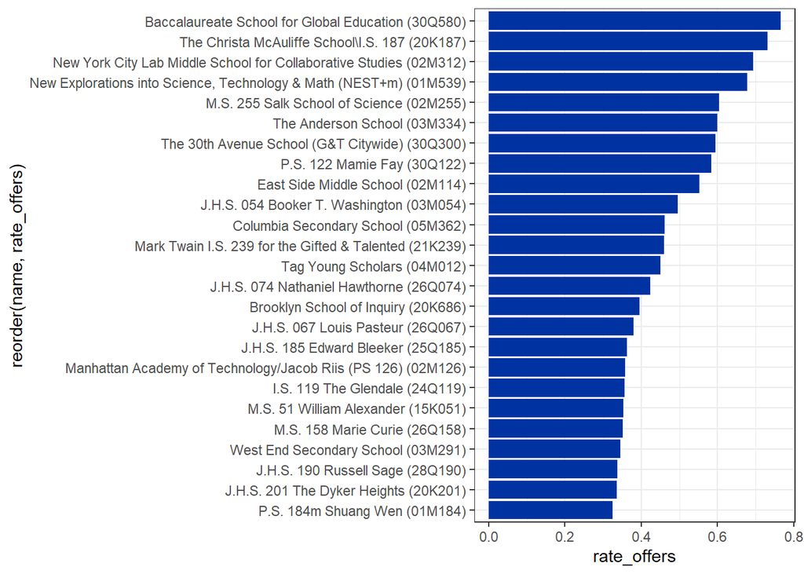

```r
ggplot( head(arrange(schools2020, desc(rate_offers)), n = 25), aes(x= reorder(name, rate_offers), y=rate_offers) ) +
  geom_bar(stat = "identity", fill="#0033a1") +
  coord_flip() +
  theme_bw()
```

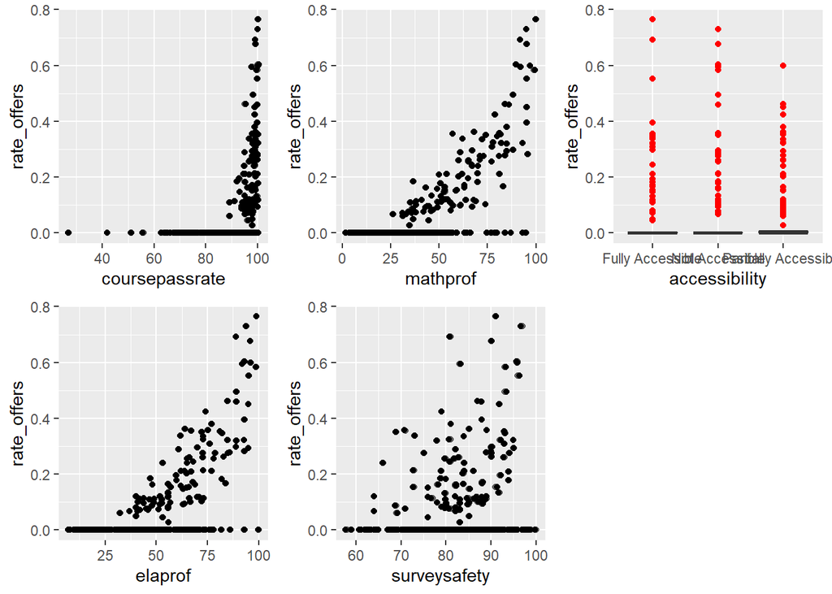

```r
p1 <- ggplot(data=model_data[model_data$year == 2020, ], aes(x=coursepassrate, y=rate_offers)) + geom_point(alpha=0.5) + geom_jitter()
p2 <- ggplot(data=model_data[model_data$year == 2020, ], aes(x=elaprof, y=rate_offers)) + geom_point(alpha=0.5) + geom_jitter()
p3 <- ggplot(data=model_data[model_data$year == 2020, ], aes(x=mathprof, y=rate_offers)) + geom_point(alpha=0.5) + geom_jitter()
p4 <- ggplot(data=model_data[model_data$year == 2020, ], aes(x=surveysafety, y=rate_offers)) + geom_point(alpha=0.5) + geom_jitter()
p5 <- ggplot(data=model_data[model_data$year == 2020, ], aes(x=accessibility, y=rate_offers)) + geom_boxplot() + geom_boxplot(outlier.colour = "red")

multiplot(p1, p2, p3, p4, p5, cols=3)
```

```r
# Cor plots
ggcorr(schools2021[, c(5,7,8,9,10,11,12,13,14,15,16)], label = T, hjust= 0.9)
```

[output not shown]

### 2021

```r
print(dfSummary(schools2021, graph.magnif=0.75), method="render")
```

Data Frame Summary

schools2021

**Dimensions**: 458 x 16  
**Duplicates**: 0

| **No** | **Variable** | **Stats / Values** | **Freqs (% of Valid)** | **Graph** | **Valid** | **Missing** |
| --- | --- | --- | --- | --- | --- | --- |
| 1 | schooldbn [character] | 1. 01M034 2. 01M140 3. 01M184 4. 01M188 5. 01M332 6. 01M378 7. 01M450 8. 01M539 9. 01M839 10. 02M104 [ 448 others ] | 1 ( 0.2% ) 1 ( 0.2% ) 1 ( 0.2% ) 1 ( 0.2% ) 1 ( 0.2% ) 1 ( 0.2% ) 1 ( 0.2% ) 1 ( 0.2% ) 1 ( 0.2% ) 1 ( 0.2% ) 448 ( 97.8% ) |  | 458 (100.0%) | 0 (0.0%) |
| 2 | district [numeric] | Mean (sd) : 16 (9.4) min ≤ med ≤ max: 1 ≤ 15 ≤ 32 IQR (CV) : 16 (0.6) | 32 distinct values |  | 458 (100.0%) | 0 (0.0%) |
| 3 | name [character] | 1. Academy for College Prepa 2. Academy for New Americans 3. Academy For Personal Lead 4. Academy for Young Writers 5. Academy of Applied Mathem 6. Academy of Arts and Lette 7. Academy of Medical Tech… | 1 ( 0.2% ) 1 ( 0.2% ) 1 ( 0.2% ) 1 ( 0.2% ) 1 ( 0.2% ) 1 ( 0.2% ) 1 ( 0.2% ) 1 ( 0.2% ) 1 ( 0.2% ) 1 ( 0.2% ) 448 ( 97.8% ) |  | 458 (100.0%) | 0 (0.0%) |
| 4 | year [numeric] | 1 distinct value | 2021 : 458 ( 100.0% ) |  | 458 (100.0%) | 0 (0.0%) |
| 5 | coursepassrate [numeric] | Mean (sd) : 91.7 (8.8) min ≤ med ≤ max: 39 ≤ 94 ≤ 100 IQR (CV) : 9.8 (0.1) | 41 distinct values |  | 458 (100.0%) | 0 (0.0%) |
| 6 | accessibility [character] | 1. Fully Accessible 2. Not Accessible 3. Partially Accessible | 124 ( 27.1% ) 184 ( 40.2% ) 150 ( 32.8% ) |  | 458 (100.0%) | 0 (0.0%) |
| 7 | elaprof [numeric] | Mean (sd) : 43.4 (21) min ≤ med ≤ max: 2 ≤ 38 ≤ 100 IQR (CV) : 31.5 (0.5) | 87 distinct values |  | 458 (100.0%) | 0 (0.0%) |
| 8 | mathprof [numeric] | Mean (sd) : 38.6 (23.4) min ≤ med ≤ max: 1 ≤ 33.5 ≤ 100 IQR (CV) : 36 (0.6) | 93 distinct values |  | 458 (100.0%) | 0 (0.0%) |
| 9 | totalstudents [numeric] | Mean (sd) : 625.5 (397.7) min ≤ med ≤ max: 85 ≤ 524.5 ≤ 2265 IQR (CV) : 449 (0.6) | 380 distinct values |  | 458 (100.0%) | 0 (0.0%) |
| 10 | surveysafety [numeric] | Mean (sd) : 82.9 (8.2) min ≤ med ≤ max: 57 ≤ 84 ≤ 100 IQR (CV) : 11 (0.1) | 41 distinct values |  | 457 (99.8%) | 1 (0.2%) |
| 11 | dual_program [numeric] | Min : 0 Mean : 0.1 Max : 1 | 0 : 399 ( 87.1% ) 1 : 59 ( 12.9% ) |  | 458 (100.0%) | 0 (0.0%) |
| 12 | shsat_prep [numeric] | Min : 0 Mean : 0.3 Max : 1 | 0 : 324 ( 70.7% ) 1 : 134 ( 29.3% ) |  | 458 (100.0%) | 0 (0.0%) |
| 13 | student_count [numeric] | Mean (sd) : 139.4 (127.7) min ≤ med ≤ max: 12 ≤ 95 ≤ 764 IQR (CV) : 82.8 (0.9) | 209 distinct values |  | 458 (100.0%) | 0 (0.0%) |
| 14 | testers_count [numeric] | Mean (sd) : 41.4 (59) min ≤ med ≤ max: 0 ≤ 20 ≤ 374 IQR (CV) : 36.8 (1.4) | 121 distinct values |  | 458 (100.0%) | 0 (0.0%) |
| 15 | offers_count [numeric] | Mean (sd) : 7.3 (21.6) min ≤ med ≤ max: 0 ≤ 0 ≤ 221 IQR (CV) : 0 (3) | 49 distinct values |  | 458 (100.0%) | 0 (0.0%) |
| 16 | rate_offers [numeric] | Mean (sd) : 0.1 (0.1) min ≤ med ≤ max: 0 ≤ 0 ≤ 0.8 IQR (CV) : 0 (2.3) | 98 distinct values |  | 458 (100.0%) | 0 (0.0%) |

Generated by summarytools 1.0.0 ([R](https://www.r-project.org/) version 4.1.3)  
2022-05-04

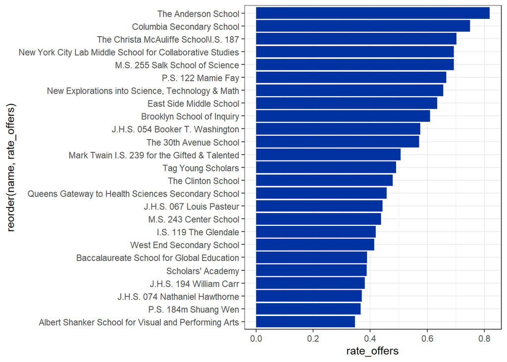

```r
ggplot( head(arrange(schools2021, desc(rate_offers)), n = 25), aes(x= reorder(name, rate_offers), y=rate_offers) ) +
  geom_bar(stat = "identity", fill="#0033a1") +
  coord_flip() +
  theme_bw()
```

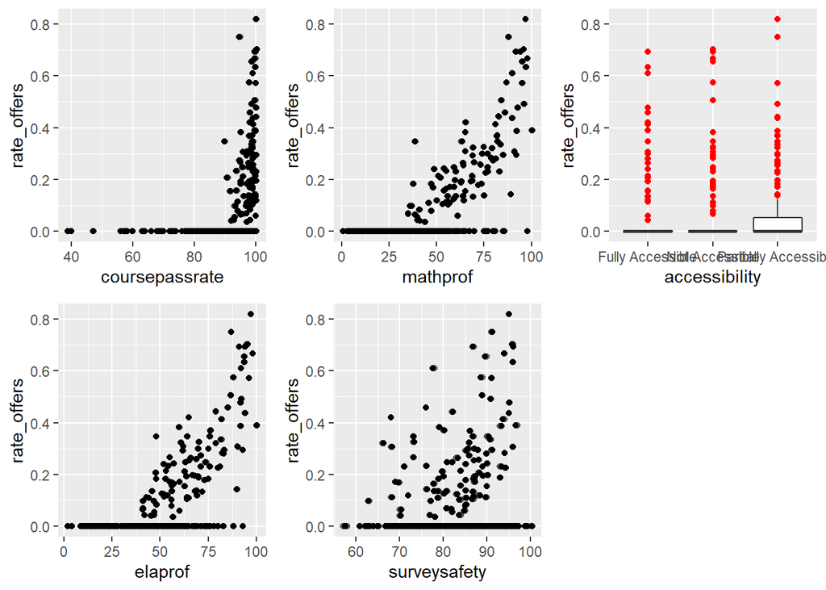

```r
p1 <- ggplot(data=model_data[model_data$year == 2021, ], aes(x=coursepassrate, y=rate_offers)) + geom_point(alpha=0.5) + geom_jitter()
p2 <- ggplot(data=model_data[model_data$year == 2021, ], aes(x=elaprof, y=rate_offers)) + geom_point(alpha=0.5) + geom_jitter()
p3 <- ggplot(data=model_data[model_data$year == 2021, ], aes(x=mathprof, y=rate_offers)) + geom_point(alpha=0.5) + geom_jitter()
p4 <- ggplot(data=model_data[model_data$year == 2021, ], aes(x=surveysafety, y=rate_offers)) + geom_point(alpha=0.5) + geom_jitter()
p5 <- ggplot(data=model_data[model_data$year == 2021, ], aes(x=accessibility, y=rate_offers)) + geom_boxplot() + geom_boxplot(outlier.colour = "red")

multiplot(p1, p2, p3, p4, p5, cols=3)
```

```r
# Cor plots
ggcorr(schools2021[, c(5,7,8,9,10,11,12,13,14,15,16)], label = T, hjust= 0.9)
```

[output not shown]

# Experimentation & Results

## Decision Tree

The following creates training and testing partitions for the data and constructs a decision tree. From the correlation plot, I decided to use `offers_count ~ testers_count + student_count + elaprof + mathprof + coursepassrate`.

### Building the Tree

```r
set.seed(422)
data_split <- initial_split(model_data, prop = 0.8, strata = district)
schools_train <- training(data_split)
schools_test <- testing(data_split)

model_spec <- decision_tree() %>%
  set_mode("regression") %>%
  set_engine("rpart")

model_spec
```

```
## Decision Tree Model Specification (regression)
##
## Computational engine: rpart
```

```r
# Train the model
model <- model_spec %>%
  fit(offers_count ~ testers_count + student_count + elaprof + mathprof + coursepassrate,
      data = schools_train)

# Information about the model
model
```

```
## parsnip model object
##
## n= 1260
##
## node), split, n, deviance, yval
##       * denotes terminal node
##
##  1) root 1260 637081.600   8.1722220
##    2) testers_count< 198.5 1195 180419.700   4.4702930
##      4) testers_count< 100.5 1089  42853.570   2.1698810
##        8) mathprof< 64.5 990  11025.070   0.9050505 *
##        9) mathprof>=64.5 99  14406.730  14.8181800 *
##      5) testers_count>=100.5 106  72597.860  28.1037700
##       10) mathprof< 88.5 94  25154.000  21.0000000
##         20) mathprof< 53.5 56   3919.982  12.5178600 *
##         21) mathprof>=53.5 38  11267.500  33.5000000 *
##       11) mathprof>=88.5 12   5542.250  83.7500000 *
##    3) testers_count>=198.5 65 139207.500  76.2307700
##      6) elaprof< 82.5 53  44108.750  60.2830200
##       12) mathprof< 62.5 20   7415.200  33.2000000 *
##       13) mathprof>=62.5 33  13132.970  76.6969700 *
##      7) elaprof>=82.5 12  22084.670 146.6667000 *
```

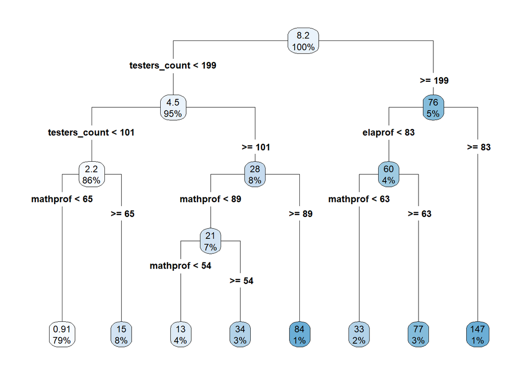

```r
# A plot of the model
model$fit  %>% rpart.plot(type = 4, roundint=FALSE)
```

### Performance of the Tree

```r
# Declare Mean Absolute Error function
MAE <- function(actual, predicted){
  mean(abs(actual - predicted))
}


# Generate the predictions using the test data
predictions <- predict(model, new_data = schools_test)

# Truncate the preductions
predictions$.pred <- trunc(predictions$.pred)

# Calculate the mean absolute error
mae_decisiontree_model <- MAE(schools_test$offers_count, predictions$.pred)
```

The mean absolute error of the decision tree is **3.2025316**.

## First Model

```r
first_model <- lm(offers_count ~ coursepassrate + elaprof + mathprof + surveysafety, data=schools_train)
summary(first_model)
```

```
##
## Call:
## lm(formula = offers_count ~ coursepassrate + elaprof + mathprof +
##     surveysafety, data = schools_train)
##
## Residuals:
##     Min      1Q  Median      3Q     Max
## -41.759  -8.576  -0.876   4.711 175.620
##
## Coefficients:
##                Estimate Std. Error t value Pr(>|t|)
## (Intercept)    13.31048    7.22798   1.842   0.0658 .
## coursepassrate -0.01141    0.06435  -0.177   0.8593
## elaprof        -0.15438    0.07322  -2.108   0.0352 *
## mathprof        0.70883    0.06593  10.751  < 2e-16 ***
## surveysafety   -0.27439    0.06365  -4.311 1.75e-05 ***
## ---
## Signif. codes:  0 '***' 0.001 '**' 0.01 '*' 0.05 '.' 0.1 ' ' 1
##
## Residual standard error: 18.33 on 1254 degrees of freedom
##   (1 observation deleted due to missingness)
## Multiple R-squared:  0.3386, Adjusted R-squared:  0.3365
## F-statistic: 160.5 on 4 and 1254 DF,  p-value: < 2.2e-16
```

```r
# To see the performance metrics in an orderly data frame
glance(first_model)
```

| r.squared | adj.r.squared | sigma | statistic | p.value | df | logLik | AIC | BIC | deviance | df.residual | nobs |
| --- | --- | --- | --- | --- | --- | --- | --- | --- | --- | --- | --- |
| 0.3385638 | 0.336454 | 18.33032 | 160.4686 | 5.955077e-111 | 4 | -5445.811 | 10903.62 | 10934.45 | 421344.6 | 1254 | 1259 |

```r
# To see the R-squared
wrapFTest(first_model)
```

```
## [1] "F Test summary: (R2=0.3386, F(4,1254)=160.5, p<1e-05)."
```

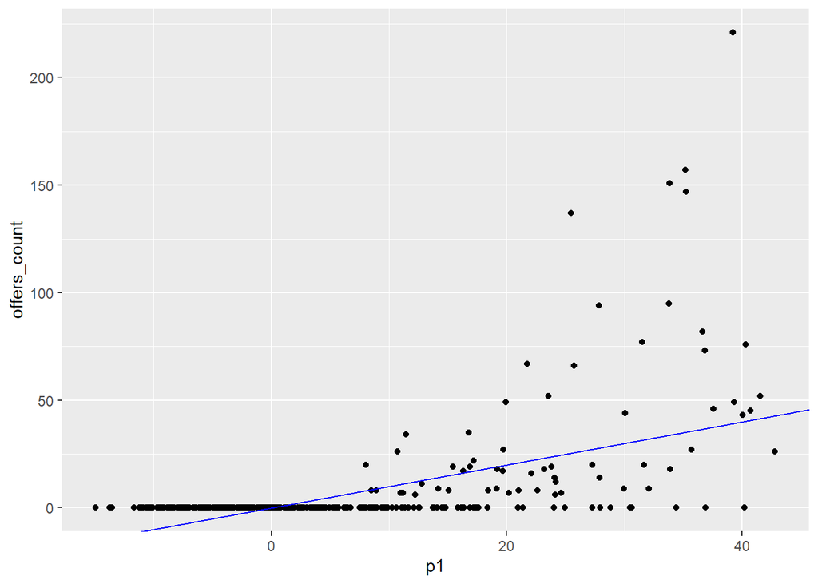

```r
## Evaluation R-2
firstmodelr_2 <- summary(first_model)$r.squared


## Use the model on the testing data

## Create the prediction column based on the model
schools_test$p1 <- predict(first_model, newdata=schools_test)

## Plot to compare the predictions to actual prediction on the x axis
ggplot(schools_test, aes(x=p1, y=offers_count)) + geom_point() + geom_abline(color="blue")
```

```r
# Calculate the RMSE
first_rmse <- schools_test %>%
  mutate(residual = p1 - offers_count) %>%
  summarize(rmse  = sqrt(mean(residual^2)))

# Get R-squared from glance and print it
(rsq_glance <- glance(first_model)$r.squared)
```

```
## [1] 0.3385638
```

The first model’s RMSE is

| rmse |
| --- |
| 20.7019 |

## Second Model

This second model uses quasipoisson for the regression because the variance is greater than the mean for `offers_count`. Because this is a quasipoisson, an AIC score cannot be generated. However, a RMSE score is created.

```r
# Quasipoisson variance is greater than the mean for offers_count
glm_second_model <- glm(offers_count  ~ testers_count + coursepassrate + elaprof + mathprof + surveysafety, data=schools_train, family=quasipoisson)

summary(glm_second_model)
```

```
##
## Call:
## glm(formula = offers_count ~ testers_count + coursepassrate +
##     elaprof + mathprof + surveysafety, family = quasipoisson,
##     data = schools_train)
##
## Deviance Residuals:
##      Min        1Q    Median        3Q       Max
## -14.6335   -1.6865   -1.0574   -0.5426   11.0786
##
## Coefficients:
##                  Estimate Std. Error t value Pr(>|t|)
## (Intercept)    -5.0429990  1.1490305  -4.389 1.23e-05 ***
## testers_count   0.0076113  0.0002519  30.220  < 2e-16 ***
## coursepassrate  0.0622752  0.0122191   5.097 3.99e-07 ***
## elaprof        -0.0178286  0.0048805  -3.653  0.00027 ***
## mathprof        0.0573938  0.0046112  12.447  < 2e-16 ***
## surveysafety   -0.0212445  0.0040421  -5.256 1.73e-07 ***
## ---
## Signif. codes:  0 '***' 0.001 '**' 0.01 '*' 0.05 '.' 0.1 ' ' 1
##
## (Dispersion parameter for quasipoisson family taken to be 7.289936)
##
##     Null deviance: 37110.5  on 1258  degrees of freedom
## Residual deviance:  6561.6  on 1253  degrees of freedom
##   (1 observation deleted due to missingness)
## AIC: NA
##
## Number of Fisher Scoring iterations: 6
```

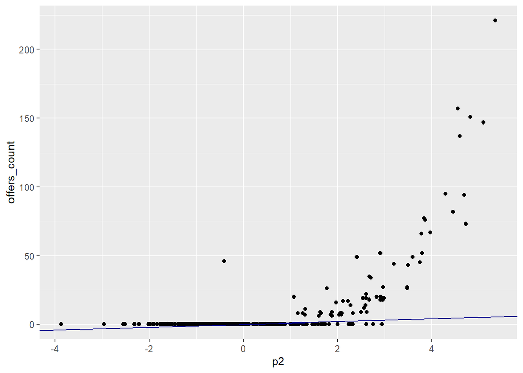

```r
schools_test$p2 <- predict(glm_second_model, newdata=schools_test)


# Calculate the RMSE
second_rmse <- schools_test %>%
  mutate(residual = p2 - offers_count) %>%
  summarize(rmse  = sqrt(mean(residual^2)))

# Plot predictions vs cnt (pred on x-axis)
ggplot(schools_test, aes(x = p2, y = offers_count)) +
  geom_point() +
  geom_abline(color = "darkblue")
```

The second model’s RMSE is

| rmse |
| --- |
| 25.1016 |

## Third Model

For this third model, I will use a zero-inflated model. Firstly, a test is done to see if one is needed. Secondly, if one is needed, then a third model is created.

```r
# Zero Inflation test for glm_second_model
check_zeroinflation(glm_second_model)
```

```
## # Check for zero-inflation
##
##    Observed zeros: 934
##   Predicted zeros: 408
##             Ratio: 0.44
```

```
## Model is underfitting zeros (probable zero-inflation).
```

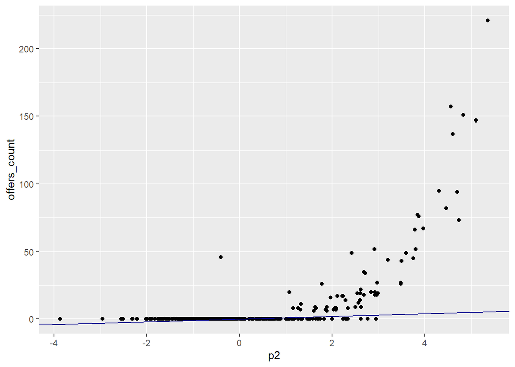

```r
zip_model <- zeroinfl(offers_count  ~ testers_count + coursepassrate + elaprof + mathprof + surveysafety, data = schools_train)


schools_test$p3 <- predict(zip_model, newdata=schools_test)


# Calculate the RMSE
third_rmse <- schools_test %>%
  mutate(residual = p2 - offers_count) %>%
  summarize(rmse  = sqrt(mean(residual^2)))

# Plot predictions vs cnt (pred on x-axis)
ggplot(schools_test, aes(x = p2, y = offers_count)) +
  geom_point() +
  geom_abline(color = "darkblue")
```

```r
summary(zip_model)
```

```
##
## Call:
## zeroinfl(formula = offers_count ~ testers_count + coursepassrate + elaprof +
##     mathprof + surveysafety, data = schools_train)
##
## Pearson residuals:
##      Min       1Q   Median       3Q      Max
## -8.39681 -0.22161 -0.07272 -0.03212  8.63169
##
## Count model coefficients (poisson with log link):
##                  Estimate Std. Error z value Pr(>|z|)
## (Intercept)     9.720e-01  3.499e-01   2.778 0.005474 **
## testers_count   6.055e-03  9.574e-05  63.240  < 2e-16 ***
## coursepassrate  6.610e-04  3.603e-03   0.183 0.854430
## elaprof        -7.009e-03  1.871e-03  -3.747 0.000179 ***
## mathprof        3.404e-02  1.749e-03  19.461  < 2e-16 ***
## surveysafety   -3.903e-03  1.600e-03  -2.440 0.014705 *
##
## Zero-inflation model coefficients (binomial with logit link):
##                 Estimate Std. Error z value Pr(>|z|)
## (Intercept)     8.128631   2.398116   3.390   0.0007 ***
## testers_count  -0.052219   0.004471 -11.678  < 2e-16 ***
## coursepassrate -0.030935   0.023298  -1.328   0.1843
## elaprof        -0.009621   0.017457  -0.551   0.5816
## mathprof       -0.075576   0.016377  -4.615 3.94e-06 ***
## surveysafety    0.029381   0.017472   1.682   0.0926 .
## ---
## Signif. codes:  0 '***' 0.001 '**' 0.01 '*' 0.05 '.' 0.1 ' ' 1
##
## Number of iterations in BFGS optimization: 17
## Log-likelihood: -1897 on 12 Df
```

The third model’s RMSE is

| rmse |
| --- |
| 25.1016 |

# Results

Though the first model has the lowest RMSE, the zero-inflated model has a better AIC measure.

```r
AIC(first_model, glm_second_model, zip_model)
```

|  | df | AIC |
| --- | --- | --- |
| first_model | 6 | 10903.622 |
| glm_second_model | 6 | NA |
| zip_model | 12 | 3818.435 |

- `elaprof`: Percent of students proficient in ELA
- `mathprof`: Percent of students proficient in math

# Summary

Because of the strong correlations between proficiency in ELA and math, I would recommend schools work to improve these proficiencies to have a better success rate for obtaining offers from Specialized High Schools (including raising awareness of the examinations and encouraging students to take them). Overall, I selected a middle school with these high variables close to my neighborhood.

Additional research can be done to look at demographics and economic data, but overall, to improve proficiencies in ELA and mathematics seem to be a viable way to go for preparing students and middle schools